# Análisis de Datos y Machine Learning

# Eliminación de variable redundante

Fijándonos en los anteriores diagramas de V5 y V4 estas dos variables parecen idénticas, vamos a comprobar si es así.

```r
frecuencia_V4 <- table(credit_original$V4)
print("Frecuencia de las categorías en V4:")
```

```
## [1] "Frecuencia de las categorías en V4:"
```

```r
print(frecuencia_V4)
```

```
##
##   l   u   y
##   2 519 163
```

```r
frecuencia_V5 <- table(credit_original$V5)
print("Frecuencia de las categorías en V5:")
```

```
## [1] "Frecuencia de las categorías en V5:"
```

```r
print(frecuencia_V5)
```

```
##
##   g  gg   p
## 519   2 163
```

De hecho ahora nos damos cuenta que V5 y V4 tienen las mismas frecuencias, vamos a comprobar si se trata de variables redundantes

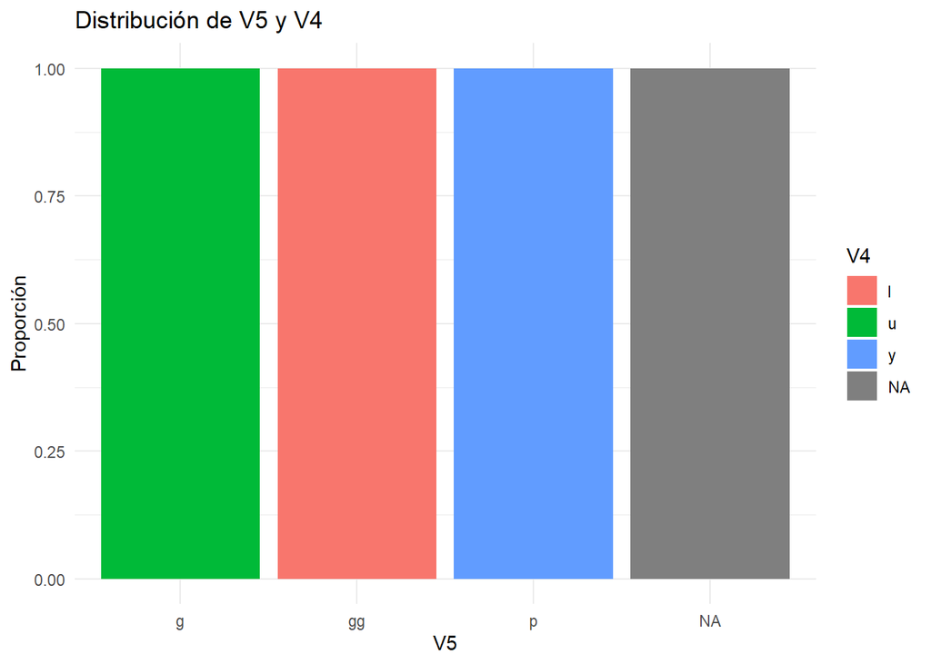

```r
library(ggplot2)

ggplot(credit_original, aes(x = V5, fill = V4)) +
  geom_bar(position = "fill") +
  labs(title = "Distribución de V5 y V4", y = "Proporción", x = "V5") +
  theme_minimal()
```

Efectivamente como podemos observar hay una correspondencia directa 1:1 entre V4 y V5 por lo que podemos eliminar una.

Eliminamos V5:

```r
credit <- credit[, !names(credit) %in% "V5"]
```

# Matriz de correlación para variables númericas

```r
numeric_vars <- credit[, sapply(credit, is.numeric)]
correlation_matrix <- cor(numeric_vars, use = "pairwise.complete.obs")
high_corr_pairs <- which(abs(correlation_matrix) > 0.8 & abs(correlation_matrix) < 1, arr.ind = TRUE)
high_corr_pairs
```

```
##      row col
```

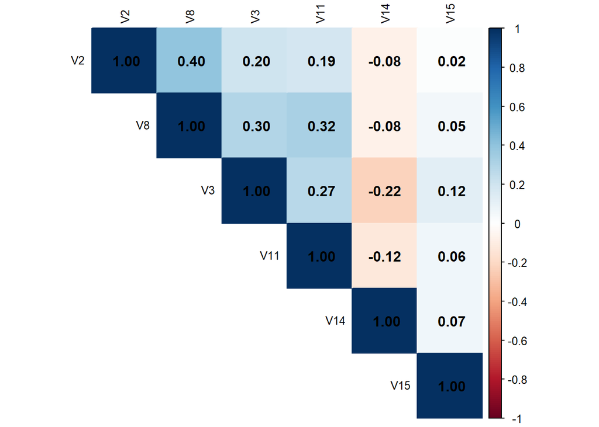

```r
library(corrplot)
corrplot(correlation_matrix, method = "color", type = "upper", order = "hclust",
         tl.col = "black", tl.cex = 0.8, addCoef.col = "black")
```

```r
dummies <- model.matrix(~ ., data = credit[, -ncol(credit)])
correlation_matrix <- cor(dummies, use = "pairwise.complete.obs")
which(abs(correlation_matrix) > 0.9 & abs(correlation_matrix) < 1, arr.ind = TRUE)
```

```
##      row col
## V4y    6   5
## V4u    5   6
## V7ff  21  11
## V6ff  11  21
```

Destacar que V2 y V8 tienen una correlación moderada. Por lo demás no hay correlaciones fuertes (0.7 o -0.7) por lo que aplicar PCA no tiene porqué ser necesario.

# Preprocesado de datos

## Paso a factores

Antes de tratar los datos, las variables categóricas deben de ser convertidas a factores, actualmente son caracteres.

```r
str(credit)
```

```
## 'data.frame':    690 obs. of  15 variables:
##  $ V1 : chr  "b" "a" "a" "b" ...
##  $ V2 : num  30.8 58.7 24.5 27.8 20.2 ...
##  $ V3 : num  0 4.46 0.5 1.54 5.62 ...
##  $ V4 : chr  "u" "u" "u" "u" ...
##  $ V6 : chr  "w" "q" "q" "w" ...
##  $ V7 : chr  "v" "h" "h" "v" ...
##  $ V8 : num  1.25 3.04 1.5 3.75 1.71 ...
##  $ V9 : chr  "t" "t" "t" "t" ...
##  $ V10: chr  "t" "t" "f" "t" ...
##  $ V11: int  1 6 0 5 0 0 0 0 0 0 ...
##  $ V12: chr  "f" "f" "f" "t" ...
##  $ V13: chr  "g" "g" "g" "g" ...
##  $ V14: int  202 43 280 100 120 360 164 80 180 52 ...
##  $ V15: int  0 560 824 3 0 0 31285 1349 314 1442 ...
##  $ V16: chr  "+" "+" "+" "+" ...
```

```r
columnas_categoricas <- names(credit)[sapply(credit, function(col) is.factor(col) || is.character(col))]
for (col in columnas_categoricas) {
  credit[[col]] <- as.factor(credit[[col]])
}
str(credit)
```

```
## 'data.frame':    690 obs. of  15 variables:
##  $ V1 : Factor w/ 2 levels "a","b": 2 1 1 2 2 2 2 1 2 2 ...
##  $ V2 : num  30.8 58.7 24.5 27.8 20.2 ...
##  $ V3 : num  0 4.46 0.5 1.54 5.62 ...
##  $ V4 : Factor w/ 3 levels "l","u","y": 2 2 2 2 2 2 2 2 3 3 ...
##  $ V6 : Factor w/ 14 levels "aa","c","cc",..: 13 11 11 13 13 10 12 3 9 13 ...
##  $ V7 : Factor w/ 9 levels "bb","dd","ff",..: 8 4 4 8 8 8 4 8 4 8 ...
##  $ V8 : num  1.25 3.04 1.5 3.75 1.71 ...
##  $ V9 : Factor w/ 2 levels "f","t": 2 2 2 2 2 2 2 2 2 2 ...
##  $ V10: Factor w/ 2 levels "f","t": 2 2 1 2 1 1 1 1 1 1 ...
##  $ V11: int  1 6 0 5 0 0 0 0 0 0 ...
##  $ V12: Factor w/ 2 levels "f","t": 1 1 1 2 1 2 2 1 1 2 ...
##  $ V13: Factor w/ 3 levels "g","p","s": 1 1 1 1 3 1 1 1 1 1 ...
##  $ V14: int  202 43 280 100 120 360 164 80 180 52 ...
##  $ V15: int  0 560 824 3 0 0 31285 1349 314 1442 ...
##  $ V16: Factor w/ 2 levels "-","+": 2 2 2 2 2 2 2 2 2 2 ...
```

```r
credit.Datos.Train<-credit[credit.trainIdx,]
credit.Datos.Test<-credit[-credit.trainIdx,]
```

## Tratamiento de valores nulos

Se puede aplicar a credit.Datos.Train solo o credit ya que credit.Datos.Test no tiene nulos:

```r
colSums(is.na(credit.Datos.Test))
```

```
##  V1  V2  V3  V4  V6  V7  V8  V9 V10 V11 V12 V13 V14 V15 V16
##   0   0   0   0   0   0   0   0   0   0   0   0   0   0   0
```

Verificación de valores nulos por columna de datos credit.Datos.Train:

```r
colSums(is.na(credit.Datos.Train))
```

```
##  V1  V2  V3  V4  V6  V7  V8  V9 V10 V11 V12 V13 V14 V15 V16
##  12  12   0   6   9   9   0   0   0   0   0   0  13   0   0
```

Para tratar los nulos en el caso de las variables categóricas, decidimos imputar los valores faltantes mediante el uso de la moda de la variable. Este método, aún introduciendo sesgo, permite mantener la coherencia estadística de los datos. No nos debemos preocupar por comprobar si al imputar un valor estamos alterando la moda ya que los valores predominantes se diferencian bastante del resto en la variable, como se puede comprobar con la tabla de frecuencias en el apartado de DEA.

```r
colSums(is.na(credit.Datos.Train))
```

```
##  V1  V2  V3  V4  V6  V7  V8  V9 V10 V11 V12 V13 V14 V15 V16
##  12  12   0   6   9   9   0   0   0   0   0   0  13   0   0
```

```r
credit.Datos.Train <- as.data.frame(lapply(credit.Datos.Train, function(x) {
  if (is.factor(x)) {
    moda <- names(sort(table(x), decreasing = TRUE))[1] # Calcular la moda
    x[is.na(x)] <- moda # Reemplazar NAs por la moda
  }
  return(x) # Retornar la columna, modificada o no
}))
```

Para tratar los valores nulos de las variables numéricas existen más métodos a tener en cuenta, pero todos introducirían un sesgo, menos el de eliminar las observaciones con datos faltantes.

Sin embargo, eso no siempre se puede hacer ya que estás perdiendo información relevante.

Por eso, hemos decidido usar un preprocesado que incluye Caret en su librería: medianImpute

Hemos elegido este debido a su robustez frente a valores atípicos y distribuciones sesgadas.

```r
colSums(is.na(credit.Datos.Train))
```

```
##  V1  V2  V3  V4  V6  V7  V8  V9 V10 V11 V12 V13 V14 V15 V16
##   0  12   0   0   0   0   0   0   0   0   0   0  13   0   0
```

```r
numeric_vars <- names(credit.Datos.Train)[sapply(credit.Datos.Train, is.numeric)]
library(caret)
ppmedian <- preProcess(credit.Datos.Train[numeric_vars],
method = c("medianImpute"),
na.remove = TRUE,
k = 5,
knnSummary = mean,
outcome = NULL,
fudge = .2,
numUnique = 3,
verbose = TRUE,
)
```

```
## Computing medians for 6 predictors... done
```

```r
credit.Datos.Train[numeric_vars] <- predict(ppmedian, credit.Datos.Train[numeric_vars])
colSums(is.na(credit.Datos.Train))
```

```
##  V1  V2  V3  V4  V6  V7  V8  V9 V10 V11 V12 V13 V14 V15 V16
##   0   0   0   0   0   0   0   0   0   0   0   0   0   0   0
```

# Entrenamiento de Modelos

## Modelo Ranger

El algoritmo Ranger combina características de dos algoritmos populares: Random Forest y Gradient Boosting. Es una implementación altamente optimizada de Random Forests y Conditional Inference Forests.

```r
library("ranger")
rangerInfo = getModelInfo("ranger")
rangerInfo = rangerInfo$ranger
rangerInfo$parameters
```

```
##       parameter     class                         label
## 1          mtry   numeric #Randomly Selected Predictors
## 2     splitrule character                Splitting Rule
## 3 min.node.size   numeric             Minimal Node Size
```

El algoritmo ranger ofrece tres parámetros: mtry: Este parámetro controla cuántos predictores se seleccionan aleatoriamente para considerar en cada división del árbol.

Con un valor bajo de mtry hay más aleatoriedad, mayor diversidad entre los árboles, pero puede disminuir la precisión. Con un valor alto de de mtry (cercano al número total de predictores): Menos aleatoriedad, los árboles son más similares entre sí, pero pueden perder robustez ante sobreajuste.

splitrule: Define cómo el modelo decide la mejor división en cada nodo del árbol.

min.node.size: Especifica el número mínimo de observaciones que un nodo debe contener para que el árbol pueda dividirlo aún más.Si es un valor pequeño, los árboles crecen más profundamente, lo que puede llevar a modelos más complejos que pueden sobreajustarse a los datos.

Hay otro parámetro que no se ofrece directamente mirando en R, pero que se puede consultar en la documentación: num.trees y class.weights

El parámetro num.trees en Ranger (y en general en algoritmos de Random Forests) especifica la cantidad de árboles de decisión que se construirán en el bosque aleatorio.

El parámetro class.weights permite asignar pesos a las clases para tener en cuenta problemas de desbalance de clases.

Realmente está hecho para casos extremos de desbalanceo como podría ser 90% y 10% pero quizás podría tener impacto en nuestros datos.

Vamos a detallar una estrategia para la generación del grid de valores para hiperparámetros a usar.

```r
rangerInfo = getModelInfo("ranger")
rangerInfo = rangerInfo$ranger
rangerInfo$parameters
```

```
##       parameter     class                         label
## 1          mtry   numeric #Randomly Selected Predictors
## 2     splitrule character                Splitting Rule
## 3 min.node.size   numeric             Minimal Node Size
```

```r
rangerInfo$grid
```

```
## function (x, y, len = NULL, search = "grid")
## {
##     if (search == "grid") {
##         srule <- if (is.factor(y))
##             "gini"
##         else "variance"
##         out <- expand.grid(mtry = caret::var_seq(p = ncol(x),
##             classification = is.factor(y), len = len), min.node.size = ifelse(is.factor(y),
##             1, 5), splitrule = c(srule, "extratrees")[1:min(2,
##             len)])
##     }
##     else {
##         srules <- if (is.factor(y))
##             c("gini", "extratrees")
##         else c("variance", "extratrees", "maxstat")
##         out <- data.frame(min.node.size = sample(1:(min(20, nrow(x))),
##             size = len, replace = TRUE), mtry = sample(1:ncol(x),
##             size = len, replace = TRUE), splitrule = sample(srules,
##             size = len, replace = TRUE))
##     }
## }
```

Ponemos especial énfasis en expand.grid.

Se preparan los parámetros que salían en la especificación de R:

mtry utiliza una función de caret: var_seq para generar valores según el número de predictores.

min.node.size elige 1 si es un problema de clasificación y 5 si es un problema de regresión.

splitrule utiliza “gini” y “extratrees” si es un problema de clasificación y “variance” y “extratrees” si es de regresión.

Solo podemos añadir en este grid de parámetros los que nos muestra R al preguntar por estos, los parámetros ocultos no se pueden incluir.

```r
mygrid = expand.grid(mtry = 1:5,
                     splitrule = c("gini", "extratrees"),
                     min.node.size = 1:3
)

print(mygrid)
```

```
##    mtry  splitrule min.node.size
## 1     1       gini             1
## 2     2       gini             1
## 3     3       gini             1
## 4     4       gini             1
## 5     5       gini             1
## 6     1 extratrees             1
## 7     2 extratrees             1
## 8     3 extratrees             1
## 9     4 extratrees             1
## 10    5 extratrees             1
## 11    1       gini             2
## 12    2       gini             2
## 13    3       gini             2
## 14    4       gini             2
```

[output cut: 16 more lines]

num.trees al ser tan importante, hemos decidido usarlo también de manera externa al grid de parámetros.

Se usará una validación cruzada de 10 pliegues para evitar el sesgo y la varianza que podría surgir al usar una única partición del conjunto de datos en el entrenamiento.

```r
levels(credit.Datos.Train$V16) <- make.names(levels(credit.Datos.Train$V16), unique = TRUE)
levels(credit.Datos.Test$V16) <- make.names(levels(credit.Datos.Test$V16), unique = TRUE)

fitControl <- trainControl(
  method = "cv",
  number = 10,
  classProbs = TRUE,  # Activar predicciones de probabilidades
  summaryFunction = defaultSummary
)
set.seed(1234)
listaModelos = list()
for(i in c(100,200,300,400,500,600)){
  rangerFit <- train(
  V16 ~ .,
  data = credit.Datos.Train,
  method = "ranger",
  trControl = fitControl,
  num.trees = i,
  class.weights = c(0.4449275, 0.5550725),
  tuneGrid = mygrid,
  importance = 'impurity',
  )
  listaModelos[[as.character(i)]] = rangerFit
}

# Recorriendo cada modelo de la lista
for(i in names(listaModelos)) {
  modelo <- listaModelos[[i]]  # Obtener el modelo correspondiente

  # Extraer la mejor precisión
  mejor_accuracy <- max(modelo$results$Accuracy)


  cat("\nModelo con", i, "árboles:\n")
  cat("Mejor precisión:", mejor_accuracy, "\n")


  cat("Mejor configuración (bestTune):\n")
  cat("mtry: ", modelo$bestTune$mtry, "\n")
  cat("splitrule: ", modelo$bestTune$splitrule, "\n")
  cat("min.node.size: ", modelo$bestTune$min.node.size, "\n")

}
```

```
##
## Modelo con 100 árboles:
## Mejor precisión: 0.87902
## Mejor configuración (bestTune):
## mtry:  3
## splitrule:  2
## min.node.size:  2
##
## Modelo con 200 árboles:
## Mejor precisión: 0.8860979
## Mejor configuración (bestTune):
## mtry:  4
## splitrule:  1
## min.node.size:  3
##
## Modelo con 300 árboles:
## Mejor precisión: 0.8753163
## Mejor configuración (bestTune):
## mtry:  4
## splitrule:  1
## min.node.size:  2
##
## Modelo con 400 árboles:
## Mejor precisión: 0.8733033
## Mejor configuración (bestTune):
## mtry:  3
## splitrule:  1
## min.node.size:  3
##
## Modelo con 500 árboles:
## Mejor precisión: 0.8861544
## Mejor configuración (bestTune):
## mtry:  5
## splitrule:  1
## min.node.size:  3
##
## Modelo con 600 árboles:
## Mejor precisión: 0.8859091
## Mejor configuración (bestTune):
## mtry:  3
## splitrule:  1
## min.node.size:  2
```

```r
modeloRanger <- listaModelos[["500"]]
```

Esto indica que el mejor valor para num.trees es 500. Si afináramos más el grano sobre num.trees:

```r
set.seed(1234)
listaModelos = list()
for(i in c(450,475,500,525,550)){
  rangerFit <- train(
  V16 ~ .,
  data = credit.Datos.Train,
  method = "ranger",
  trControl = fitControl,
  num.trees = i,
  class.weights = c(0.4449275, 0.5550725),
  tuneGrid=mygrid
  )
  listaModelos[[as.character(i)]] = rangerFit
}

# Recorriendo cada modelo de la lista
for(i in names(listaModelos)) {
  modelo <- listaModelos[[i]]  # Obtener el modelo correspondiente

  # Extraer la mejor precisión
  mejor_accuracy <- max(modelo$results$Accuracy)  # Obtener la mejor precisión

  # Imprimir la mejor precisión y la mejor configuración
  cat("\nModelo con", i, "árboles:\n")
  cat("Mejor precisión:", mejor_accuracy, "\n")

}
```

```
##
## Modelo con 450 árboles:
## Mejor precisión: 0.8807732
##
## Modelo con 475 árboles:
## Mejor precisión: 0.8824615
##
## Modelo con 500 árboles:
## Mejor precisión: 0.878919
##
## Modelo con 525 árboles:
## Mejor precisión: 0.8768747
##
## Modelo con 550 árboles:
## Mejor precisión: 0.8880051
```

```r
modeloRanger <- listaModelos[["550"]]
listaModelos = list()
```

Ha mejorado solamente un 0,2%. Esto se puede deber a la componente aleatoria de Random Forests (por ejemplo: al elegir las características con mtry). Pero si no vemos una mejora, es porque realmente no importa afinar más el grano.

Dicho esto, nos quedaremos con el mejor modelo.

Probaremos si la precisión se mantiene con los datos de entrenamiento del modelo.

```r
pred.train <- predict(modeloRanger , credit.Datos.Train)
pred <- factor(pred.train)
real <- factor(credit.Datos.Train$V16)
confusionMatrix(pred, real)
```

```
## Confusion Matrix and Statistics
##
##           Reference
## Prediction  X. X..1
##       X.   304    1
##       X..1   3  245
##
##                Accuracy : 0.9928
##                  95% CI : (0.9816, 0.998)
##     No Information Rate : 0.5552
##     P-Value [Acc > NIR] : <2e-16
##
##                   Kappa : 0.9854
##
##  Mcnemar's Test P-Value : 0.6171
##
##             Sensitivity : 0.9902
##             Specificity : 0.9959
##          Pos Pred Value : 0.9967
##          Neg Pred Value : 0.9879
##              Prevalence : 0.5552
##          Detection Rate : 0.5497
##    Detection Prevalence : 0.5515
##       Balanced Accuracy : 0.9931
##
##        'Positive' Class : X.
##
```

La precisión se acerca mucho al 100%. Ahora vamos a probar con los datos de Test.

```r
pred.test <- predict(modeloRanger , credit.Datos.Test)
pred <- factor(pred.test)
real <- factor(credit.Datos.Test$V16)
confusionMatrix(pred, real)
```

```
## Confusion Matrix and Statistics
##
##           Reference
## Prediction X. X..1
##       X.   61    7
##       X..1 15   54
##
##                Accuracy : 0.8394
##                  95% CI : (0.767, 0.8965)
##     No Information Rate : 0.5547
##     P-Value [Acc > NIR] : 1.375e-12
##
##                   Kappa : 0.6791
##
##  Mcnemar's Test P-Value : 0.1356
##
##             Sensitivity : 0.8026
##             Specificity : 0.8852
##          Pos Pred Value : 0.8971
##          Neg Pred Value : 0.7826
##              Prevalence : 0.5547
##          Detection Rate : 0.4453
##    Detection Prevalence : 0.4964
##       Balanced Accuracy : 0.8439
##
##        'Positive' Class : X.
##
```

```r
library(pROC)
```

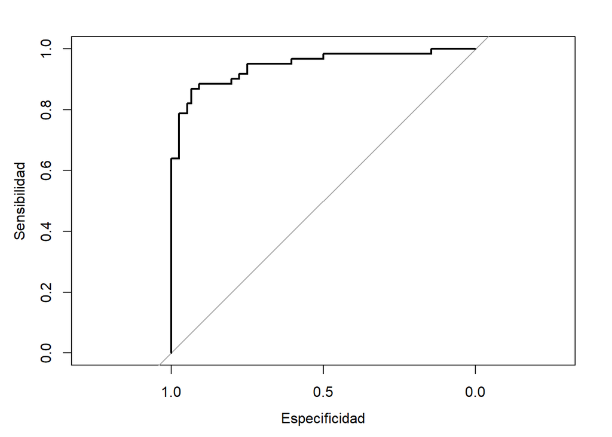

```r
probs1 <- predict(modeloRanger, newdata = credit.Datos.Test, type = "prob")

roc_curve1 <- roc(credit.Datos.Test$V16, probs1[, 2])
plot(roc_curve1, xlab = "Especificidad", ylab = "Sensibilidad")
```

```r
auc_value1 <- auc(roc_curve1)
print(auc_value1)
```

```
## Area under the curve: 0.9459
```

Obtenemos una precisión razonable cercana al 85%, por lo que el modelo funciona correctamente.

Es normal ver una pequeña bajada en la precisión del modelo ante los datos de train y test.

Con este preprocesado de los datos alternativo, optamos por eliminar los valores fuera de rango y centrar y escalar los valores para ver si podría traer mejoras en la precisión.

Para ello, vamos a transformar los datos (añadiendo un sesgo) para que los outliers sean convertidos usando esta definición de outlier que encontramos en el manual de Caret:

Un outlier es aquel punto que está más allá de 3/2 de la diferencia entre los valores Q3 y Q1 medida desde la mediana.

Después aprovechamos que no existen los valores fuera de rango para utilizar otro preprocesado sensible a ellos como es el de knnVecinos, que también transforma las variables numéricas para que estén centradas y escaladas.

```r
credit.Datos.Train.lim<-credit[credit.trainIdx,]
credit.Datos.Test.lim<-credit[-credit.trainIdx,]

credit.Datos.Train.lim <- as.data.frame(lapply(credit.Datos.Train.lim, function(x) {
  if (is.factor(x)) {
    moda <- names(sort(table(x), decreasing = TRUE))[1] # Calcular la moda
    x[is.na(x)] <- moda # Reemplazar NAs por la moda
  }
  return(x) # Retornar la columna, modificada o no
}))


nulos_por_fila <- apply(credit.Datos.Train.lim, 1, function(x) sum(is.na(x)))
# Filtrar las filas que tienen 5 o menos NA
credit.Datos.Train.lim <- credit.Datos.Train.lim[nulos_por_fila <= 4, ]

library(dplyr)
# Función para calcular límites basados en la mediana y el rango intercuartílico
calcular_limites_mediana <- function(x) {
  mediana <- median(x, na.rm = TRUE)
  Q1 <- quantile(x, 0.25, na.rm = TRUE)
  Q3 <- quantile(x, 0.75, na.rm = TRUE)
  IQR <- Q3 - Q1
  limite_inferior <- mediana - (3/2) * IQR
  limite_superior <- mediana + (3/2) * IQR
  return(c(limite_inferior, limite_superior))
}

# Función para cortar valores fuera del rango
clipping_mediana <- function(x) {
  limites <- calcular_limites_mediana(x)
  x[x < limites[1]] <- limites[1]  # Reemplaza valores menores al límite inferior
  x[x > limites[2]] <- limites[2]  # Reemplaza valores mayores al límite superior
  return(x)
}

mostrar_valores_fuera_de_rango <- function(x, var_name) {
  limites <- calcular_limites_mediana(x)
  fuera_de_rango <- x[x < limites[1] | x > limites[2]]
  if (length(fuera_de_rango) > 0) {
    cat("\nVariable:", var_name, "\n")
    cat("Límite inferior:", limites[1], " | Límite superior:", limites[2], "\n")
    cat("Valores fuera de rango:\n")
    cat("Número de valores fuera de rango:", length(fuera_de_rango), "\n")
  }
}

# Aplicar a todas las columnas numéricas y mostrar la información
numeric_vars <- credit.Datos.Train.lim %>% select(where(is.numeric))
lapply(names(numeric_vars), function(var) {
  mostrar_valores_fuera_de_rango(numeric_vars[[var]], var)
})
```

```
##
## Variable: V2
## Límite inferior: 5.585  | Límite superior: 50.075
## Valores fuera de rango:
## Número de valores fuera de rango: 59
##
## Variable: V3
## Límite inferior: -7  | Límite superior: 12.5
## Valores fuera de rango:
## Número de valores fuera de rango: 45
##
## Variable: V8
## Límite inferior: -2.5025  | Límite superior: 4.5025
## Valores fuera de rango:
## Número de valores fuera de rango: 77
##
## Variable: V11
## Límite inferior: -4.5  | Límite superior: 4.5
## Valores fuera de rango:
## Número de valores fuera de rango: 111
##
## Variable: V14
## Límite inferior: -150.5  | Límite superior: 470.5
## Valores fuera de rango:
## Número de valores fuera de rango: 39
##
## Variable: V15
## Límite inferior: -595  | Límite superior: 605
## Valores fuera de rango:
## Número de valores fuera de rango: 110
```

```r
credit.Datos.Train.lim <- credit.Datos.Train.lim %>%
  mutate(across(where(is.numeric), clipping_mediana))

numeric_vars <- credit.Datos.Train.lim %>% select(where(is.numeric))
lapply(names(numeric_vars), function(var) {
  mostrar_valores_fuera_de_rango(numeric_vars[[var]], var)
})
```

```
##
## Variable: V2
## Límite inferior: 5.585  | Límite superior: 50.075
## Valores fuera de rango:
## Número de valores fuera de rango: 12
##
## Variable: V14
## Límite inferior: -150.5  | Límite superior: 470.5
## Valores fuera de rango:
## Número de valores fuera de rango: 13
```

```r
colSums(is.na(credit.Datos.Train.lim))
```

```
##  V1  V2  V3  V4  V6  V7  V8  V9 V10 V11 V12 V13 V14 V15 V16
##   0  12   0   0   0   0   0   0   0   0   0   0  13   0   0
```

```r
numeric_vars <- names(credit.Datos.Train.lim)[sapply(credit.Datos.Train.lim, is.numeric)]
library(caret)
ppmedian <- preProcess(credit.Datos.Train.lim[numeric_vars],
method = c("knnImpute"),
na.remove = TRUE,
k = 5,
knnSummary = mean,
outcome = NULL,
fudge = .2,
numUnique = 3,
verbose = TRUE,
)
```

```
## Calculating 6 means for centering
## Calculating 6 standard deviations for scaling
```

```r
credit.Datos.Train.lim[numeric_vars] <- predict(ppmedian, credit.Datos.Train.lim[numeric_vars])
credit.Datos.Test.lim[numeric_vars] <- predict(ppmedian, newdata = credit.Datos.Test.lim[numeric_vars])
colSums(is.na(credit.Datos.Train.lim))
```

```
##  V1  V2  V3  V4  V6  V7  V8  V9 V10 V11 V12 V13 V14 V15 V16
##   0   0   0   0   0   0   0   0   0   0   0   0   0   0   0
```

```r
set.seed(1234)
levels(credit.Datos.Train.lim$V16) <- make.names(levels(credit.Datos.Train.lim$V16), unique = TRUE)
levels(credit.Datos.Test.lim$V16) <- make.names(levels(credit.Datos.Test.lim$V16), unique = TRUE)
listaModelos = list()
for(i in c(100,200,300,400,500,600)){
  rangerFit <- train(
  V16 ~ .,
  data = credit.Datos.Train.lim,
  method = "ranger",
  trControl = fitControl,
  num.trees = i,
  class.weights = c(0.4449275, 0.5550725),
  tuneGrid = mygrid,
  importance = 'impurity'  # Para obtener la importancia de las variables
  )
  listaModelos[[as.character(i)]] = rangerFit
}
# Recorriendo cada modelo de la lista
for(i in names(listaModelos)) {
  modelo <- listaModelos[[i]]  # Obtener el modelo correspondiente

  # Extraer la mejor precisión
  mejor_accuracy <- max(modelo$results$Accuracy)  # Obtener la mejor precisión

  # Imprimir la mejor precisión y la mejor configuración
  cat("\nModelo con", i, "árboles:\n")
  cat("Mejor precisión:", mejor_accuracy, "\n")

  # Imprimir la mejor configuración de hiperparámetros
  cat("Mejor configuración (bestTune):\n")
  # Imprimir los valores específicos de 'bestTune'
  cat("mtry: ", modelo$bestTune$mtry, "\n")
  cat("splitrule: ", modelo$bestTune$splitrule, "\n")
  cat("min.node.size: ", modelo$bestTune$min.node.size, "\n")

}
```

```
##
## Modelo con 100 árboles:
## Mejor precisión: 0.8807071
## Mejor configuración (bestTune):
## mtry:  5
## splitrule:  2
## min.node.size:  3
##
## Modelo con 200 árboles:
## Mejor precisión: 0.8788901
## Mejor configuración (bestTune):
## mtry:  4
## splitrule:  1
## min.node.size:  2
##
## Modelo con 300 árboles:
## Mejor precisión: 0.8805075
## Mejor configuración (bestTune):
## mtry:  3
## splitrule:  1
## min.node.size:  1
##
## Modelo con 400 árboles:
## Mejor precisión: 0.8787578
## Mejor configuración (bestTune):
## mtry:  4
## splitrule:  1
## min.node.size:  3
##
## Modelo con 500 árboles:
## Mejor precisión: 0.8843362
## Mejor configuración (bestTune):
## mtry:  4
## splitrule:  1
## min.node.size:  3
##
## Modelo con 600 árboles:
## Mejor precisión: 0.8859416
## Mejor configuración (bestTune):
## mtry:  3
## splitrule:  1
## min.node.size:  2
```

```r
modeloRanger <- listaModelos[["600"]]
```

```r
pred.test <- predict(modeloRanger , credit.Datos.Test.lim)
pred <- factor(pred.test)
real <- factor(credit.Datos.Test.lim$V16)
confusionMatrix(pred, real)
```

```
## Confusion Matrix and Statistics
##
##           Reference
## Prediction X. X..1
##       X.   66    7
##       X..1 10   54
##
##                Accuracy : 0.8759
##                  95% CI : (0.8088, 0.926)
##     No Information Rate : 0.5547
##     P-Value [Acc > NIR] : 5.29e-16
##
##                   Kappa : 0.75
##
##  Mcnemar's Test P-Value : 0.6276
##
##             Sensitivity : 0.8684
##             Specificity : 0.8852
##          Pos Pred Value : 0.9041
##          Neg Pred Value : 0.8438
##              Prevalence : 0.5547
##          Detection Rate : 0.4818
##    Detection Prevalence : 0.5328
##       Balanced Accuracy : 0.8768
##
##        'Positive' Class : X.
##
```

Conseguimos mejorar en un 3% la precisión indicando que este preprocesado alternativo es mejor para este algoritmo, desde un punto de vista estadístico.

## Modelo GLM

El Modelo de Regresión Generalizada es una herramienta poderosa en el análisis estadístico que se utiliza para modelar relaciones entre variables continuas y/o categóricas. Es una extensión de los modelos de regresión lineal que permite manejar datos que no siguen una distribución normal o linealmente dependiente de una variable independiente. Este modelo integra una función de enlace y una familia de distribución, permitiendo así que las variables dependientes no estén limitadas a una distribución normal.

El modelo GLM se entrenó usando caret, un paquete en R que facilita el proceso de entrenamiento de modelos mediante validación cruzada. A continuación se muestran los parámetros y la configuración utilizados:

-Función de enlace: Por defecto, caret utiliza una función de enlace lineal (identity), bajo la suposición de una distribución normal para la variable dependiente (gaussian).

-Pre-procesamiento: Se aplicó centrado y escalado a las variables predictoras (preProcess = c(“center”, “scale”)) para normalizar las escalas y evitar problemas de convergencia y overfitting.

-Validación cruzada: Se utilizó un método de validación cruzada de 10 pliegues para evaluar la robustez del modelo. Esta técnica permite probar el modelo en múltiples conjuntos de entrenamiento y validación, proporcionando una estimación más robusta del rendimiento.

```r
caret.glm <- train(
  V16 ~ .,
  data = credit.Datos.Train,
  method = "glm",
  preProcess = c("center", "scale"),  # Normalización de datos
  trControl = trainControl(method = "cv", number = 10)  # Validación cruzada
)
print(caret.glm)
```

```
## Generalized Linear Model
##
## 553 samples
##  14 predictor
##   2 classes: 'X.', 'X..1'
##
## Pre-processing: centered (35), scaled (35)
## Resampling: Cross-Validated (10 fold)
## Summary of sample sizes: 497, 498, 497, 498, 498, 499, ...
## Resampling results:
##
##   Accuracy   Kappa
##   0.8463215  0.6909483
```

Los resultados obtenidos tras el proceso de validación cruzada son los siguientes:

Accuracy: 0.85 aproximadamente, indicando que el modelo predice correctamente la clase en el 85% de los casos en el conjunto de validación cruzada. Kappa: 0.7 aproximadamente, muestra una fuerte concordancia entre las predicciones del modelo y las clases observadas en el conjunto de validación. Este valor Kappa sugiere que hay una buena coincidencia entre las categorías predichas y las reales. Resampling Results: Los resultados de la validación cruzada revelan una distribución equilibrada de las clases en los diferentes pliegues, lo que indica que el modelo tiene una buena capacidad de generalización.

Una vez que se completó el entrenamiento del modelo GLM utilizando la técnica de validación cruzada y el pre-procesamiento de datos, se procedió a evaluar su desempeño en el conjunto de test.

```r
columnas_categoricas <- names(credit.Datos.Train)[sapply(credit.Datos.Train, function(col) is.factor(col) || is.character(col))]
for (col in columnas_categoricas) {
  credit.Datos.Test[[col]] <- as.factor(credit.Datos.Test[[col]])
}
```

Utilizando el modelo GLM entrenado, se van a hacer predicciones en el conjunto de test mediante la función predict(). Esto proporcionará las clases predichas para cada observación en el conjunto de test.

```r
predicciones_test <- predict(caret.glm, newdata = credit.Datos.Test)
```

Con las predicciones obtenidas, se construye la matriz de confusión para evaluar la precisión, sensibilidad, especificidad y otros criterios de desempeño del modelo. La matriz de confusión compara las clases predichas por el modelo con las clases reales en el conjunto de test.

```r
matriz_confusion <- confusionMatrix(predicciones_test, credit.Datos.Test$V16)
print(matriz_confusion)
```

```
## Confusion Matrix and Statistics
##
##           Reference
## Prediction X. X..1
##       X.   59    7
##       X..1 17   54
##
##                Accuracy : 0.8248
##                  95% CI : (0.7506, 0.8844)
##     No Information Rate : 0.5547
##     P-Value [Acc > NIR] : 2.175e-11
##
##                   Kappa : 0.651
##
##  Mcnemar's Test P-Value : 0.06619
##
##             Sensitivity : 0.7763
##             Specificity : 0.8852
##          Pos Pred Value : 0.8939
##          Neg Pred Value : 0.7606
##              Prevalence : 0.5547
##          Detection Rate : 0.4307
##    Detection Prevalence : 0.4818
##       Balanced Accuracy : 0.8308
##
##        'Positive' Class : X.
##
```

Tras completar el entrenamiento del modelo Generalized Linear Model (GLM) y evaluarlo en el conjunto de test, se obtuvieron los siguientes resultados:

Matriz de Confusión:

La matriz de confusión reveló que el modelo GLM logró una precisión del 82% aproximadamente con un intervalo de confianza del 95% que oscila entre 0.7506 y 0.8844. Esto indica que el modelo acierta en la clasificación de las clases con alta precisión. El valor de Kappa fue 0.651 aproximadamente, sugiriendo una relación moderada entre las clasificaciones predichas y las reales, con un nivel de acuerdo significativo. La prueba de McNemar proporcionó un valor p de 0.06619, indicando que las diferencias observadas no son estadísticamente significativas, lo que sugiere que el modelo no sobreajusta a las clases de manera excesiva.

Sensibilidad y Especificidad:

La sensibilidad del modelo (tasa de verdaderos positivos) fue del 77%, indicando que el modelo identifica correctamente a las observaciones negativas. La especificidad (tasa de verdaderos negativos) fue del 88%, demostrando una alta capacidad para rechazar observaciones que no pertenecen a la clase positiva. El valor de la Precisión Positiva fue del 89%, lo que sugiere que cuando el modelo predice positivamente, la mayoría de las veces es correcto. La Precisión Negativa fue del 76%, demostrando una buena capacidad para predecir observaciones negativas.

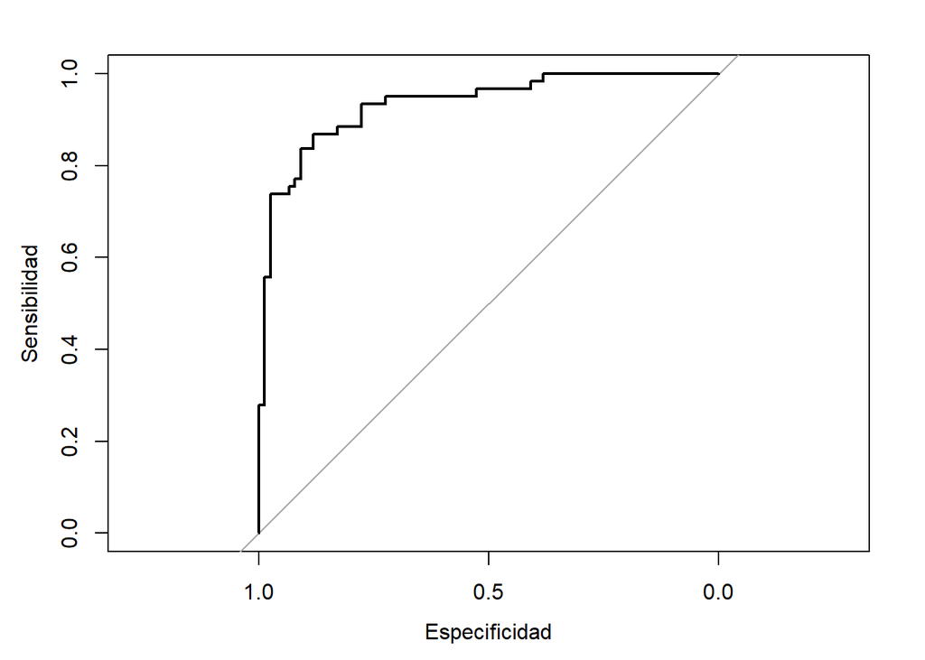

```r
library(pROC)

probs1 <- predict(caret.glm, newdata = credit.Datos.Test, type = "prob")

roc_curve1 <- roc(credit.Datos.Test$V16, probs1[, 2])
plot(roc_curve1, xlab = "Especificidad", ylab = "Sensibilidad")
```

```r
auc_value1 <- auc(roc_curve1)
print(auc_value1)
```

```
## Area under the curve: 0.9333
```

Al evaluar el modelo mediante la métrica del Área Bajo la Curva (AUC), el valor obtenido fue 0.9333, lo que indica que el modelo tiene una alta capacidad discriminativa entre las clases positivas y negativas.

## Algoritmo nnet

El algoritmo nnet es una implementación de redes neuronales artificiales que utiliza un conjunto de capas interconectadas para modelar relaciones complejas entre las variables de entrada (predictores) y la variable objetivo (respuesta). El modelo aprende ajustando los pesos de las conexiones entre las neuronas en las diferentes capas mediante un proceso de optimización basado en el gradiente descendente.

```r
library(caret)
modelLookup("nnet")
```

```
##   model parameter         label forReg forClass probModel
## 1  nnet      size #Hidden Units   TRUE     TRUE      TRUE
## 2  nnet     decay  Weight Decay   TRUE     TRUE      TRUE
```

Los hiper-parametros son:

- Size: Especifica el número de neuronas en la capa oculta. Más neuronas capturan relaciones complejas pero aumenta el riesto de overfitting.
- Decay: Controla la penalización aplicada a los pesos de las conexiones para evitar el overfitting (sobreajuste).

Otro parametro importante es maxit que indica el número de iteracciones. Ciertos modelos necesitarán más o menos iteraciones para converger.

```r
set.seed(1231)
formula <- V16 ~ .
tuneGrid <- expand.grid(size = seq(2, 8, by = 2), decay = c(0.001, 0.01, 0.1))
tuneGrid.ref1 <- expand.grid(size = 1:4, decay = seq(0.002, 0.008, by = 0.001))
tuneGrid.ref2 <- expand.grid(size = 2*1:5, decay = c(0.001, 0.0035, 0.0055))
tuneGrid.ref3 <- expand.grid(size = 1:4, decay = seq(0.001, 0.01, by = 0.0015))
caret.nnet <- train(formula,
                    data = train_data,
                    method = "nnet",
                    preProc = c("center", "scale"),
                    tuneGrid = tuneGrid.ref1,
                    trControl = trainControl(method = "cv", number = 10),
                    trace = FALSE,
                    maxit = 150)

summary(caret.nnet$finalModel)
```

```
## a 35-2-1 network with 75 weights
## options were - entropy fitting  decay=0.004
##   b->h1  i1->h1  i2->h1  i3->h1  i4->h1  i5->h1  i6->h1  i7->h1  i8->h1  i9->h1
##    5.06    1.11   -2.71   -0.23   -1.57    1.62   -3.04   -3.48   -0.38    1.39
## i10->h1 i11->h1 i12->h1 i13->h1 i14->h1 i15->h1 i16->h1 i17->h1 i18->h1 i19->h1
##    2.15    1.53    0.14    0.20    1.26    3.32   -0.38   -1.75   -1.30   -1.04
## i20->h1 i21->h1 i22->h1 i23->h1 i24->h1 i25->h1 i26->h1 i27->h1 i28->h1 i29->h1
##    1.77   -4.98   -2.75   -0.42   -0.30   -1.28    0.29   -0.21  -17.48   -2.89
## i30->h1 i31->h1 i32->h1 i33->h1 i34->h1 i35->h1
##    2.30   -3.88   -3.02    0.43    3.13   -8.96
##   b->h2  i1->h2  i2->h2  i3->h2  i4->h2  i5->h2  i6->h2  i7->h2  i8->h2  i9->h2
##    5.11    1.09    2.30    1.80   -1.05    1.11    1.76   -0.54    0.33   -2.28
## i10->h2 i11->h2 i12->h2 i13->h2 i14->h2 i15->h2 i16->h2 i17->h2 i18->h2 i19->h2
##    1.47    0.56    0.14    2.80   -2.07   -5.39   -0.39   -6.90   -0.95    0.47
## i20->h2 i21->h2 i22->h2 i23->h2 i24->h2 i25->h2 i26->h2 i27->h2 i28->h2 i29->h2
##    1.39   -0.72    0.23   -0.89   -0.32    1.39   -0.63    0.59  -14.02   -3.69
## i30->h2 i31->h2 i32->h2 i33->h2 i34->h2 i35->h2
##   -8.42    3.62   -3.18    4.15    1.84   -1.77
##   b->o  h1->o  h2->o
##   2.99  -3.50  -3.10
```

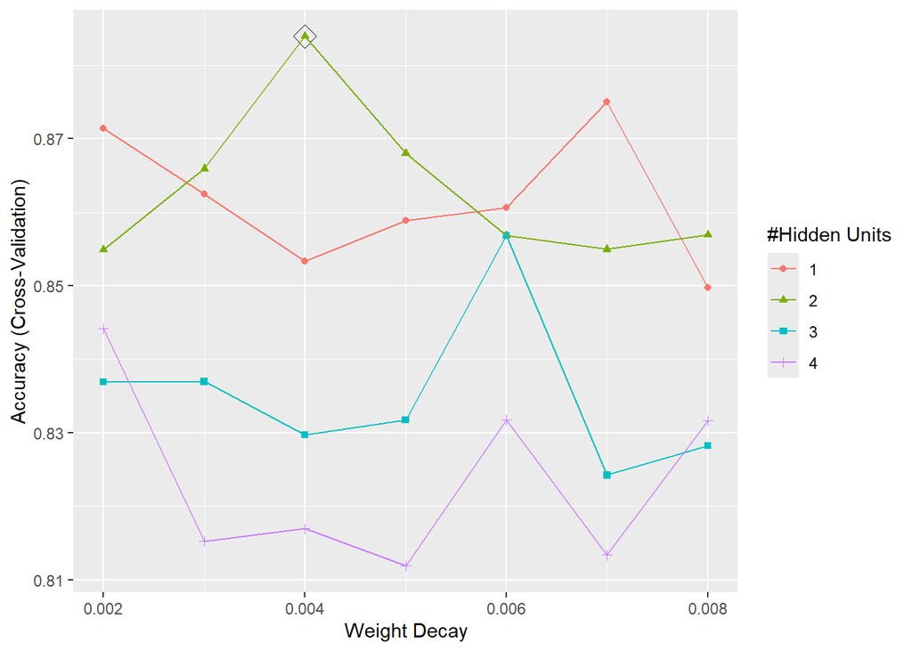

```r
ggplot(caret.nnet, highlight = TRUE)
```

```r
predictions <- predict(caret.nnet, newdata = test_data)
conf_matrix <- confusionMatrix(predictions, test_data$V16)
print(conf_matrix)
```

```
## Confusion Matrix and Statistics
##
##           Reference
## Prediction X. X..1
##       X.   67   10
##       X..1  9   51
##
##                Accuracy : 0.8613
##                  95% CI : (0.7919, 0.9144)
##     No Information Rate : 0.5547
##     P-Value [Acc > NIR] : 1.464e-14
##
##                   Kappa : 0.7188
##
##  Mcnemar's Test P-Value : 1
##
##             Sensitivity : 0.8816
##             Specificity : 0.8361
##          Pos Pred Value : 0.8701
##          Neg Pred Value : 0.8500
##              Prevalence : 0.5547
##          Detection Rate : 0.4891
##    Detection Prevalence : 0.5620
##       Balanced Accuracy : 0.8588
##
##        'Positive' Class : X.
##
```

A medida que aumenta el número de unidades ocultas, la precisión del modelo tiende a disminuir. El mejor rendimiento (máxima precisión) se observa para un número pequeño de unidades ocultas (2) y para el valor de Weight Decay = 0.004.

Respecto a la ‘Confusion Matrix’: - Accuracy: el 86.13% de las observaciones han sido clasificadas correctamente es una buena precisión global. - Kappa: Indica un nivel alto de acuerdo entre predicciones y valores reales. - No information rate: si siempre predices (-), tendrías una precisión de 55.47%. La precisión del modelo (86.13%) es mucho mayor, lo que demuestra que el modelo está aprendiendo algo útil.

- Test McNemar: el modelo no muestra sesgo hacia ninguna de las clases.

-Tanto la sensibilidad como la especificidad son altas (88.16% y 83.61%, respectivamente), lo que indica que el modelo clasifica bien ambas clases.

El modelo tiene un desempeño sólido y equilibrado, con alta precisión global (86.13%) y un buen balance entre sensibilidad y especificidad.

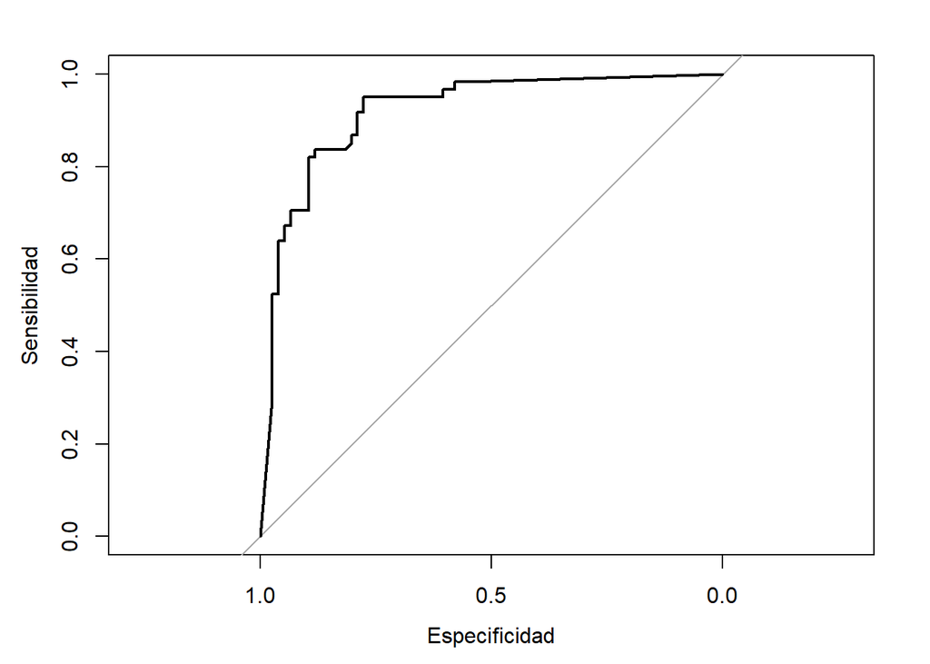

```r
library(pROC)
probs1 <- predict(caret.nnet, newdata = test_data, type = "prob")
roc_curve1 <- roc(test_data$V16, probs1[, 2])
plot(roc_curve1, xlab = "Especificidad", ylab = "Sensibilidad")
```

```r
auc_value1 <- auc(roc_curve1)
print(auc_value1)
```

```
## Area under the curve: 0.9184
```

Como podemos observar a través de la Curva ROC y del AUC (0.9184) el modelo tiene un buen rendimiento para distinguir entre las clases (AUC cercana a 1 indicaría un modelo casi perfecto). La curva sube rápidamente al principio, lo que significa que el modelo logra una alta sensibilidad con pocos falsos positivos.

## Yeo-Jhonson, preprocesado alternativo para ‘nnet’

Vamos a probar ahora a transformar los datos y tratar las asímetrías de las variables numéricas y comprobar si esto influye positivamente en nuestro modelo y si podemos alcanzar un modelo más preciso.

```r
library(caret)
library(e1071)
numeric_vars<- numeric_vars[sapply(numeric_vars, is.numeric)]
skewness_values1 <- sapply(numeric_vars, skewness, na.rm = TRUE)
print(skewness_values1)
```

```
## named list()
```

```r
numeric_vars <- train_data[, sapply(train_data, is.numeric)]


preproc <- preProcess(numeric_vars, method = "YeoJohnson")

train_data_transformed <- train_data
train_data_transformed[, names(numeric_vars)] <- predict(preproc, numeric_vars)

test_data_transformed <- test_data
test_data_transformed[, names(numeric_vars)] <- predict(preproc, test_data[, names(numeric_vars)])

skewness_values2 <- sapply(train_data_transformed[, names(numeric_vars)], skewness, na.rm = TRUE)
print(skewness_values2)
```

```
##          V2          V3          V8         V11         V14         V15
##  0.05220426  0.03959124  0.19871248  0.52953745 -0.33069273  0.23608502
```

```r
set.seed(1231)
caret.nnet.yj <- train(
  formula,
  data = train_data_transformed,
  method = "nnet",
  preProc = c("center", "scale"),
  tuneGrid = tuneGrid.ref2,
  trControl = trainControl(method = "cv", number = 10),
  trace = FALSE,
  maxit = 150
)
summary(caret.nnet.yj$finalModel)
```

```
## a 35-2-1 network with 75 weights
## options were - entropy fitting  decay=0.0035
##   b->h1  i1->h1  i2->h1  i3->h1  i4->h1  i5->h1  i6->h1  i7->h1  i8->h1  i9->h1
##   -3.24   -0.09   -0.14    0.18   -0.64   -0.81   -0.12    0.47   -0.03    1.59
## i10->h1 i11->h1 i12->h1 i13->h1 i14->h1 i15->h1 i16->h1 i17->h1 i18->h1 i19->h1
##   -1.41    0.33   -0.57   -0.10    0.96   -0.04    0.06    0.19    0.28   -0.32
## i20->h1 i21->h1 i22->h1 i23->h1 i24->h1 i25->h1 i26->h1 i27->h1 i28->h1 i29->h1
##    1.82    0.18    0.56    0.72   -4.29   -0.20   -0.21   -0.21    3.98   -0.25
## i30->h1 i31->h1 i32->h1 i33->h1 i34->h1 i35->h1
##    0.61   -0.04   -3.65    2.05   -0.37    0.41
##   b->h2  i1->h2  i2->h2  i3->h2  i4->h2  i5->h2  i6->h2  i7->h2  i8->h2  i9->h2
##  -10.23    2.43   -5.07    2.06   -0.30    0.36   -2.19    1.24   -2.79    3.11
## i10->h2 i11->h2 i12->h2 i13->h2 i14->h2 i15->h2 i16->h2 i17->h2 i18->h2 i19->h2
##    4.68    5.41    2.99    2.08    1.66   -2.97    0.48   -2.42   -7.13    0.13
## i20->h2 i21->h2 i22->h2 i23->h2 i24->h2 i25->h2 i26->h2 i27->h2 i28->h2 i29->h2
##    4.39   -0.22   -0.64    0.31    0.81    0.73    2.04   -4.34   -5.18   -3.28
## i30->h2 i31->h2 i32->h2 i33->h2 i34->h2 i35->h2
##   -1.35    5.29    0.60    6.84    6.39    3.35
##   b->o  h1->o  h2->o
##  -1.89   7.80  -6.41
```

```r
predictions.yj <- predict(caret.nnet.yj, newdata = test_data_transformed)
conf_matrix.yj <- confusionMatrix(predictions.yj, test_data_transformed$V16)
print(conf_matrix.yj)
```

```
## Confusion Matrix and Statistics
##
##           Reference
## Prediction X. X..1
##       X.   64    7
##       X..1 12   54
##
##                Accuracy : 0.8613
##                  95% CI : (0.7919, 0.9144)
##     No Information Rate : 0.5547
##     P-Value [Acc > NIR] : 1.464e-14
##
##                   Kappa : 0.7215
##
##  Mcnemar's Test P-Value : 0.3588
##
##             Sensitivity : 0.8421
##             Specificity : 0.8852
##          Pos Pred Value : 0.9014
##          Neg Pred Value : 0.8182
##              Prevalence : 0.5547
##          Detection Rate : 0.4672
##    Detection Prevalence : 0.5182
##       Balanced Accuracy : 0.8637
##
##        'Positive' Class : X.
##
```

- Accuracy: El porcentaje de predicciones correctas es idéntico al anterior.
- Kappa: Es ligeramente mayor, indica una mejor concordancia entre las predicciones y los valores reales.
- Test McNemar: El modelo tiene una distribución de errores razonablemente balanceada entre las clases. Aunque algo más desbalanceada.

Mejor predicción en las predicciones positivas, esto puede ser beneficioso en el contexto en el que nos encontramos, datos bancarios.

```r
library(pROC)
probs1 <- predict(caret.nnet, newdata = test_data, type = "prob")
roc_curve1 <- roc(test_data$V16, probs1[, 2])
auc_value1 <- auc(roc_curve1)
print(auc_value1)
```

```
## Area under the curve: 0.9184
```

## Algoritmo svmRadial

El algoritmo svmRadial utiliza un modelo de máquinas de soporte vectorial con un kernel radial. Este enfoque es útil para problemas no lineales, ya que el kernel radial transforma los datos en un espacio de mayor dimensión donde se pueden separar linealmente.

```r
library(caret)
modelLookup("svmRadial")
```

```
##       model parameter label forReg forClass probModel
## 1 svmRadial     sigma Sigma   TRUE     TRUE      TRUE
## 2 svmRadial         C  Cost   TRUE     TRUE      TRUE
```

Hiper-parámetros:

- Sigma: Parámetro que determina la influencia de cada punto de datos en el modelo cuando se usa un núcleo radial (RBF). Controla la forma del kernel.
- C: Controla la compensación entre un margen más amplio y la clasificación correcta de todos los puntos de entrenamiento. Un valor alto de C hace que el modelo se enfoque en minimizar los errores de clasificación (margen estrecho), mientras que un valor bajo hace que el modelo sea más tolerante a errores (margen amplio).

```r
library(caret)

niveles_originales <- levels(train_data$V16)
levels(train_data$V16) <- make.names(levels(train_data$V16), unique = TRUE)
levels(test_data$V16) <- make.names(levels(test_data$V16), unique = TRUE)

tuneGrid.svm <- expand.grid(C = c(0.1, 0.15, 0.2), sigma = c(0.01, 0.05, 0.1))
tuneGrid.svm.ref <- expand.grid(C = c(0.1, 0.2, 0.25), sigma = seq(0.005, 0.02, by = 0.0015))

train.control.svm <- trainControl(method = "cv", number = 10, classProbs = TRUE, summaryFunction = twoClassSummary)

set.seed(1232)
caret.svm <- train(
  V16 ~ .,
  data = train_data,
  method = "svmRadial",
  tuneGrid = tuneGrid.svm,
  metric = "ROC",
  trControl = train.control.svm,
  preProc = c("center", "scale") # Normalizar los datos
)
print(caret.svm$bestTune)
```

```
##   sigma   C
## 7  0.01 0.2
```

```r
predictions.svm <- predict(caret.svm, newdata = test_data)
conf_matrix.svm <- confusionMatrix(predictions.svm, test_data$V16)
print(conf_matrix.svm)
```

```
## Confusion Matrix and Statistics
##
##           Reference
## Prediction X. X..1
##       X.   61    6
##       X..1 15   55
##
##                Accuracy : 0.8467
##                  95% CI : (0.7753, 0.9025)
##     No Information Rate : 0.5547
##     P-Value [Acc > NIR] : 3.197e-13
##
##                   Kappa : 0.6942
##
##  Mcnemar's Test P-Value : 0.08086
##
##             Sensitivity : 0.8026
##             Specificity : 0.9016
##          Pos Pred Value : 0.9104
##          Neg Pred Value : 0.7857
##              Prevalence : 0.5547
##          Detection Rate : 0.4453
##    Detection Prevalence : 0.4891
##       Balanced Accuracy : 0.8521
##
##        'Positive' Class : X.
##
```

Este modelo tiene una alta precisión (84.67%) y es particularmente bueno clasificando la clase negativa (-) con una especificidad de 90.16% y un muy buen valor predictivo positivo.

```r
roc_curve_nnet <- roc(test_data$V16, predict(caret.nnet, newdata = test_data, type = "prob")[, 2])
roc_curve_svm <- roc(test_data$V16, predict(caret.svm, newdata = test_data, type = "prob")[, 2])
print(auc(roc_curve_nnet))
```

```
## Area under the curve: 0.9184
```

```r
print(auc(roc_curve_svm))
```

```
## Area under the curve: 0.931
```

El modelo svmRadial ofrece un mejor rendimiento en términos de capacidad discriminativa (AUC = 0.931).

# Comparación de modelos

Comparando los resultados de los 4 modelos y posibles/distintos pre procesados, teniendo en cuenta el contexto en el que nos encontramos (datos bancarios), si por ejemplo pensáramos que la V16 es el visto bueno a un préstamo, lo más interesante sería buscar un modelo que discrimine bien entre las dos clases y que reduzca al máximo el número de falsos positivos y así minimizara las pérdidas.

Por esto, el modelo de ‘ranger’ con los datos transformados por un preprocesado de tratamiento de nulos con knn-vecinos y tratamiento de outliers es el que mejor desempeño tiene.

Nos basamos en que en la medida principal de comparación (accuracy) es el que mejor valor obtiene con un 87.59%, además de tener una especifidad y sensibilidad muy equilibrados.

Esto implicaría que en datos nunca antes vistos, tendría una precisión similar a la que ha conseguido con los datos de test.

A pesar de que algunos modelos tienen una precisión similar aunque algo menor, sí que obtienen un menor tiempo de ejecución.

Dicho esto, si queremos obtener el mejor resultado posible a todo costo, ‘ranger’ es la mejor opción.

# Bibliografía

Algoritmo ranger: https://cran.r-project.org/web/packages/ranger/ranger.pdf

Algoritmo glm: https://topepo.github.io/caret/train-models-by-tag.html#generalized-linear-model

Algoritmo nnet: https://cran.r-project.org/web/packages/nnet/nnet.pdf

Algoritmo svmRadial: https://topepo.github.io/caret/train-models-by-tag.html#Radial_Basis_Function